# Reproducible Research Assignment 1

Samuel Danilola

22/02/2022

## R Markdown

This is an assignment that uses a personal activity monitoring data. The device collects data on an individuals activity at 5-minute interval all throught the day. he data consists of two months of data from an anonymous individual collected during the months of October and November, 2012.

This document is my attempt at responding to the Project Assignment 1 in the Coursera Reproducible Research course.

*LOAD THE REQUIRED PACKAGES*

```r
library(dplyr)
library(lubridate)
```

```r
library(ggplot2)
```

*LOAD THE DATA*

```r
activity <- read.csv("activity.csv", header = TRUE, sep = ',', colClasses = c("numeric", "character", "integer"))
```

*CONVERT DATE COLUMN TO DATE*

```r
activity$date <- ymd(activity$date)
```

1. Calculating the mean total numberof steps taken per day

```r
steps <- activity %>%
  filter(!is.na(steps)) %>%
  group_by(date) %>%
  summarize(steps = sum(steps)) %>%
  print
```

```
## # A tibble: 53 x 2
##    date       steps
##    <date>     <dbl>
##  1 2012-10-02   126
##  2 2012-10-03 11352
##  3 2012-10-04 12116
##  4 2012-10-05 13294
##  5 2012-10-06 15420
##  6 2012-10-07 11015
##  7 2012-10-09 12811
##  8 2012-10-10  9900
##  9 2012-10-11 10304
## 10 2012-10-12 17382
## # ... with 43 more rows
```

2. Constructing the histogram of steps taken per day

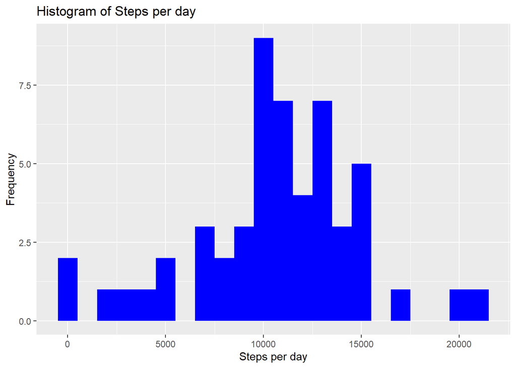

```r
ggplot(steps, aes(x = steps)) + geom_histogram(fill = "blue", binwidth = 1000) + labs(title = "Histogram of Steps per day", x = "Steps per day", y = "Frequency")
```

3. Mean and Median of the Total Number of Steps per Day

```r
mean_steps <- mean(steps$steps, na.rm = TRUE)
median_steps <- median(steps$steps, na.rm = TRUE)

mean_steps
```

```
## [1] 10766.19
```

```r
median_steps
```

```
## [1] 10765
```

*Average Daily Activity Pattern*